# Looking at pairs of features, Part 2

```python
# !pip install datascience   # You need to un-comment this line when you
                             # run the notebook on Azure
```

```python
# Import code libraries or "modules" in Python lingo

import numpy as np
import pandas as pd
import matplotlib.pyplot as plots
import seaborn as sns
import importlib
import sys
from datascience import *
sns.set_style("whitegrid")
%matplotlib inline
plots.style.use('fivethirtyeight')
```

A summary of the methods to Table is [here](http://data8.org/datascience/tables.html)  
A tutorial for the datascience module is [here](http://data8.org/datascience/tutorial.html)  
A cheatsheet for the datascience module is [here](https://github.com/wstuetzle/STAT180/blob/master/Computing/data8_sp17_midterm_ref_sheet.pdf)

**Note**

If you want to run this notebook on Azure, its easiest to upload the notebook and the file "datascience_extensions.py" (on Canvas) and then replace the cell below by a code cell with the single line

from datascience_extensions import *

```python
# Import some new methods for class Table
# Add IDS directory to search path

course_dir = "/Users/wxs/Dropbox/IDS/Git-reps/STAT180/"
computing_dir = course_dir + "Computing"

if computing_dir not in sys.path:
    sys.path.append(computing_dir)

from datascience_extensions import *

# Reload the extensions after we make a change
# Importing it again does not work - a module is imported only once
module_name = "datascience_extensions"
importlib.reload(sys.modules[module_name])
```

```
<module 'datascience_extensions' from '/Users/wxs/Dropbox/IDS/Git-reps/STAT180/Lectures/datascience_extensions.py'>
```

```python
# Read titanic-table.csv from URL
titanic_table_url = "https://github.com/wstuetzle/STAT180/raw/master/Data/titanic3-table.csv"
titanic = Table.read_table(titanic_table_url)
# titanic.show(2)
titanic.shape()
titanic_sub = titanic.drop("name", "sibsp", "parch", "ticket", "fare", "cabin", "boat",
                           "body", "home.dest").take_complete_rows()
titanic_sub.show(3)
titanic_sub.shape()
```

| pclass | survived | sex | age | embarked |
| --- | --- | --- | --- | --- |
| 1 | 1 | female | 29 | S |
| 1 | 1 | male | 0.9167 | S |
| 1 | 0 | female | 2 | S |

... (1041 rows omitted)

```
[1044, 5]
```

### Looking at a pair of a numerical and a categorical feature

For illustration take age as the numerical feature and pclass as the categorical feature.

**Two options**

1. summarize / visualize the conditional distribution of age, given pclass
2. summarize / visualize the conditional distribution of pclass, give age

**Summarize / visualize the conditional distribution of age, given pclass**

```python
# Compute the means of the conditional distribution of age, given pclass

conditional_means = titanic_sub.select("pclass", "age").group("pclass", np.mean)
conditional_means

# First class passengers tend to be much older than second or third class passengers
```

| pclass | age mean |
| --- | --- |
| 1 | 39.083 |
| 2 | 29.5067 |
| 3 | 24.8164 |

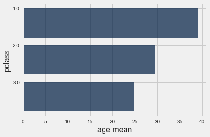

```python
# Visualize the conditional means with a bar chart

conditional_means.barh("pclass")
```

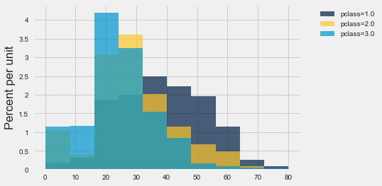

```python
# Draw histograms of the conditional distributions of age, given pclass

titanic_sub.hist("age", group = "pclass")

# Default is to overlay the histograms. Not all that useful if the
# categorical variable has more than two categories
```

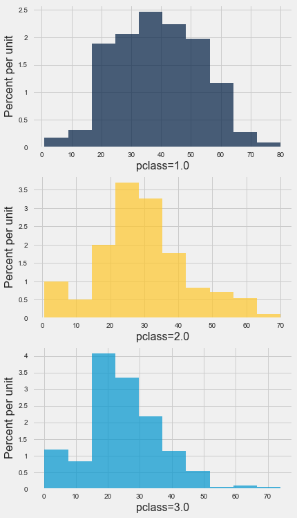

```python
# Draw individual histograms for the three categories

titanic_sub.hist("age", group = "pclass", overlay = False)
```

**Note:** Horizontal and vertical scales are not the same - **bad!**

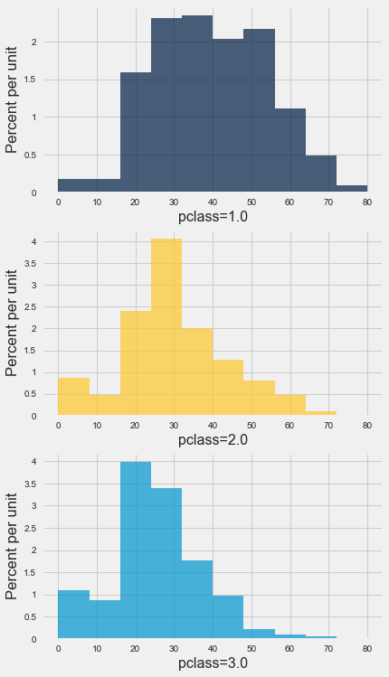

```python
# Make horizontal scales the same

titanic_sub.hist("age", group = "pclass", overlay = False, range = [0, 80])
```

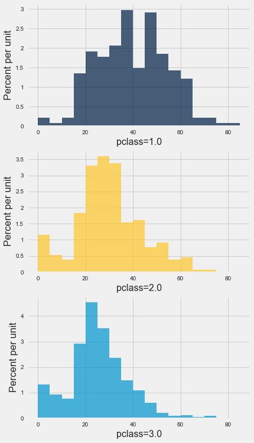

```python
# Alternatively we can specify the bin boundaries

titanic_sub.hist("age", group = "pclass", overlay = False, bins = np.arange(0, 90, 5))
```

**Note:** There appears to be no easy way to make the vertical scales the same **

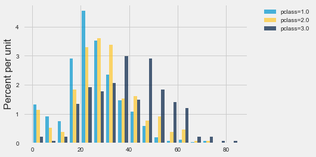

```python
# Try drawing bars for the three histograms side-by-side

titanic_sub.hist("age", group = "pclass", overlay = True, side_by_side = True, bins = np.arange(0, 90, 5))

# Something seems to be wrong here - labels in the legend incorrect ???
```

**Visualize the conditional distribution of pclass, give age ?**

```python
titanic_sub.group("age").show(10)
```

| age | count |
| --- | --- |
| 0.1667 | 1 |
| 0.3333 | 1 |
| 0.4167 | 1 |
| 0.6667 | 1 |
| 0.75 | 3 |
| 0.8333 | 3 |
| 0.9167 | 2 |
| 1 | 10 |
| 2 | 12 |
| 3 | 7 |

... (88 rows omitted)

Problem: We only have values of pclass for a discrete set of ages. So

- For most values of age we have no direct information on the conditional distribution of pclass, given age
- Even for the ages where we actually have passengers, the number of passengers will be small, and the relative frequencies of the categories will be unstable.

**Idea:** Approximate the relative frequency of the categories for some query_age by the relative frequencies in an age window centered at query_age

```python
query_age = 50      # for example
window_width = 20

in_age_interval = titanic_sub.where("age", are.between(query_age - window_width / 2,
                                                      query_age + window_width / 2))
category_count_table = in_age_interval.group("pclass")
category_count_array = category_count_table.column("count")
category_rel_freq_array = category_count_array / sum(category_count_array)
category_rel_freq_table = category_count_table.drop(1).with_column("rel_freq", category_rel_freq_array)
category_rel_freq_table
```

| pclass | rel_freq |
| --- | --- |
| 1 | 0.526829 |
| 2 | 0.234146 |
| 3 | 0.239024 |

```python
# Let's make a function that evaluates the conditional distribution of a categorical
# variable given a numerical variable on a regular grid with ngrid grid points
# and draws the relative frequencies as curves
# This is not an attempt at producing production quality code

def draw_conditional_distribution(table, categorical_feature, given_numerical_feature,
                                  ngrid, window_width):
    cat_feat = categorical_feature
    num_feat = given_numerical_feature
    num_feat_values = table.column(num_feat)
    grid = np.linspace(min(num_feat_values), max(num_feat_values), ngrid)
    ncat = table.group(cat_feat).num_rows
    cats = table.group(cat_feat).column(cat_feat)
    rel_freqs = np.zeros((ncat, ngrid))
    for i in range(ngrid):
        in_window = table.where(num_feat, are.between(grid[i] - window_width / 2,
                                                      grid[i] + window_width / 2))
        cat_values = in_window.column(cat_feat)
        for j in range(ncat):
            rel_freqs[j, i] = sum(cat_values == cats[j])
        tot = 0
        for j in range(ncat):
            tot = tot + rel_freqs[j, i]
        if (tot != 0):
            for j in range(ncat):
                rel_freqs[j, i] = rel_freqs[j, i] / tot
    rel_freq_table = Table().with_columns(num_feat, grid)
    for i in range(ncat):
        rel_freq_table = rel_freq_table.with_columns(str(cats[i]), rel_freqs[i, :])
    rel_freq_table.plot(num_feat, overlay = True)
    return rel_freq_table
```

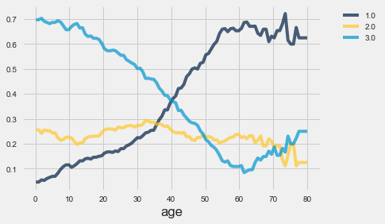

```python
rel_freq_table = draw_conditional_distribution(titanic_sub, "pclass", "age", 100, 20)

# rel_freq_table.show(20)
```

**Interpretation**

- Young passengers are predominantly in 3rd class
- Old passengers are predominantly in 1st class

The curves get very noisy beyond age 60 because there are few passengers older than 60

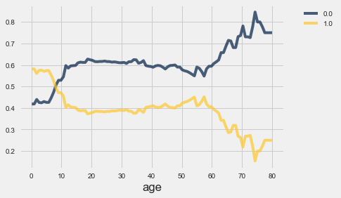

```python
# Let's look at the conditional distribution of survived, given age

rel_freq_table = draw_conditional_distribution(titanic_sub, "survived", "age", 100, 20)
```

**Note**

The symmetry in the plot is not surprising - the curves have to sum to 1.

Children uncer 10 had the righest survival rate.

Survival rate decresed for age > 60

### Looking at a pair of numerical features

```python
galton = Table.read_table('http://inferentialthinking.com/notebooks/galton.csv')
galton.show(10)
```

| family | father | mother | midparentHeight | children | childNum | gender | childHeight |
| --- | --- | --- | --- | --- | --- | --- | --- |
| 1 | 78.5 | 67 | 75.43 | 4 | 1 | male | 73.2 |
| 1 | 78.5 | 67 | 75.43 | 4 | 2 | female | 69.2 |
| 1 | 78.5 | 67 | 75.43 | 4 | 3 | female | 69 |
| 1 | 78.5 | 67 | 75.43 | 4 | 4 | female | 69 |
| 2 | 75.5 | 66.5 | 73.66 | 4 | 1 | male | 73.5 |
| 2 | 75.5 | 66.5 | 73.66 | 4 | 2 | male | 72.5 |
| 2 | 75.5 | 66.5 | 73.66 | 4 | 3 | female | 65.5 |
| 2 | 75.5 | 66.5 | 73.66 | 4 | 4 | female | 65.5 |
| 3 | 75 | 64 | 72.06 | 2 | 1 | male | 71 |
| 3 | 75 | 64 | 72.06 | 2 | 2 | female | 68 |

... (924 rows omitted)

A description of the data is [here](https://vincentarelbundock.github.io/Rdatasets/doc/HistData/GaltonFamilies.html)

```python
# Make feature names more consistent

galton = galton.relabeled(1, "fat_hei").relabeled(2, "mom_hei").relabeled(3, "mid_hei") \
         .relabeled(7, "chi_hei")
```

```python
((galton.column("fat_hei") + galton.column("mom_hei")) / 2)[1:5]
```

```
array([ 72.75,  72.75,  72.75,  71.  ])
```

**Why did Galton do that?**

```python
fat_hei_std = np.std(galton.column("fat_hei"))
mom_hei_std = np.std(galton.column("mom_hei"))
fat_hei_std / mom_hei_std
```

```
1.0810136754527109
```

He did it so that fat_hei and mom_hei would have the same influence on mid_hei

**The standard way of visualizing the distribution of a pair of numerical features is a scatterplot**

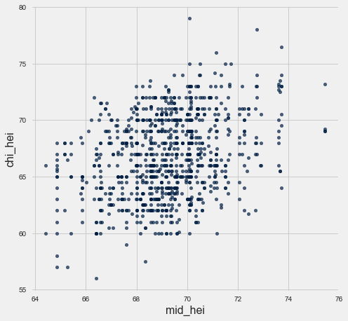

```python
galton.scatter("mid_hei", "chi_hei", width = 7, height = 7)
```

It looks like there is an association between mid_hei and chi_hei: large values of chi_hei tend to go with large values of mid_hei, and small values of chi_hei tend to go with small values of mid_hei. **Height is a partially inherited trait**

Stated more informally: chi_hei depends on mid_hei

Stated more precisely: the conditional distribution of chi_hei, given mid_hei depends on mid_hei.

- To find the conditional distribution of chi_hei, given mid_hei = 67in (just as an example) we would draw a histogram of chi_hei for all the children with mid_hei = 67in.

Let's try that.

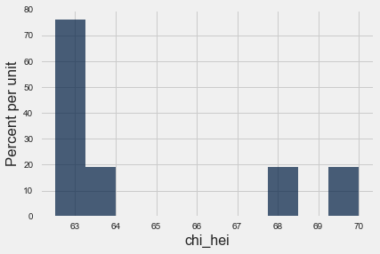

```python
mid_hei_67 = galton.where("mid_hei", are.equal_to(67))
mid_hei_67.num_rows
mid_hei_67.hist("chi_hei")
```

This histogram is not particularly informative - the number of children with mid_hei = 67in is too small. For most values of mid_hei the number of children with that particular mid_hei will be 0. Instead let's draw a histogram of chi_hei for children with mid_hei close to 67in and compute their average height

```python
def conditional_mean(table, y, x, x_query, window_width, draw_histogram = False,
                     histogram_bins = None):
    '''
    From data in table estimate the conditional mean of numerical feature y, given
    numerical feature x = x_query, by averaging the values of y for the observations
    (rows) with values of x in a window centered at x_query.
    If draw_histogram = True the function draws a histogram of the conditional distribution.
    '''
    table_sub = table.where(x, are.between(x_query - 0.5 * window_width,
                                           x_query + 0.5 * window_width))
    if draw_histogram:
        table_sub.hist(y, unit = None, bins = histogram_bins)
    return np.mean(table_sub.column(y))
```

**Note** The conditional_mean function has a problem: What if there are no observations (rows) with x values in the window? It should return a code for "undefined" and should not draw a histogram.

```
65.801290322580655
```

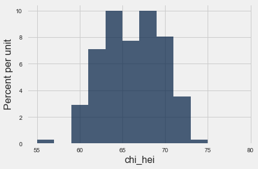

```python
query_mid_hei = 67
window_width = 2
bins = np.arange(55, 80, 2)

conditional_mean(galton, "chi_hei", "mid_hei", query_mid_hei, window_width,
                         True, bins)
```

```
67.155725190839689
```

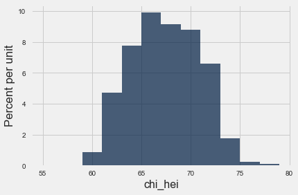

```python
query_mid_hei = 70
window_width = 2
bins = np.arange(55, 80, 2)

conditional_mean(galton, "chi_hei", "mid_hei", query_mid_hei, window_width,
                         True, bins)
```

```
69.139344262295083
```

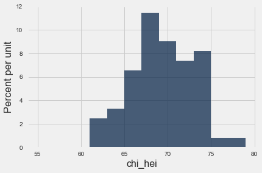

```python
query_mid_hei = 73
window_width = 2
bins = np.arange(55, 80, 2)

conditional_mean(galton, "chi_hei", "mid_hei", query_mid_hei, window_width,
                         True, bins)
```

**Conclusion**

The conditional distribution of chi_hei given mid_hei depends on the value of mid_hei. The mean of the conditional distribution (the "conditional mean") increases with mid_hei.

**Let's draw the conditional mean curve**

```python
def conditional_mean_curve(table, y, x, window_width, grid = None, plot = False):
    '''
    Plot the conditional mean of y, given x on a grid. Default grid has
    100 grid points, evenly spaced and spanning the range of the data
    '''
    if type(grid) != "numpy.ndarray":
        ngrid = 100
        x_values = table.column(x)
        grid = np.linspace(min(x_values), max(x_values), ngrid)
    else:
        ngrid = len(grid)
    cond_mean = np.zeros(ngrid)
    for i in np.arange(ngrid):
        cond_mean[i] = conditional_mean(table, y, x, grid[i], window_width)
    tab = Table().with_columns(x, grid, ("cond_mean_of_" + y), cond_mean)
    if plot:
        tab.plot(x)
    return cond_mean
```

```
array([ 64.14482759,  64.14482759,  64.14482759,  64.26451613,
        64.24146341,  64.24761905,  64.35813953,  64.48636364,  64.24827586])
```

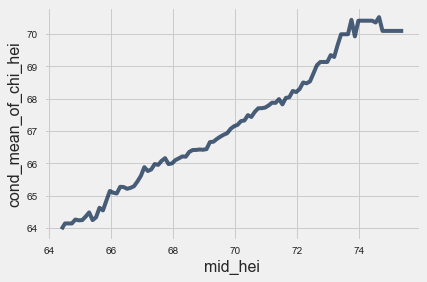

```python
cond_mean = conditional_mean_curve(galton, "chi_hei", "mid_hei", 2, plot = True)
cond_mean[1:10]
```

**Note**

- Apart from the upper extreme (where data are sparse), the curve looks almost linear.
- We should look at boys and girls separately. Showing them together muddies the waters. (Why?)

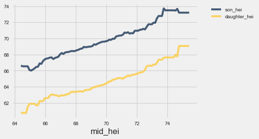

```python
# Let's calculate and plot the conditional mean of chi_hei given mid_hei
# separately for boys and girls

ngrid = 100
x = galton.column("mid_hei")
grid = np.linspace(min(x), max(x), ngrid)

galton_male = galton.where("gender", are.equal_to("male"))
galton_male_cond_mean = conditional_mean_curve(galton_male, "chi_hei", "mid_hei", 2,
                                               grid = grid)

galton_female = galton.where("gender", are.equal_to("female"))
galton_female_cond_mean = conditional_mean_curve(galton_female, "chi_hei", "mid_hei", 2,
                                               grid = grid)

tab = Table().with_columns("mid_hei", grid, "son_hei", galton_male_cond_mean,
                           "daughter_hei", galton_female_cond_mean)

tab.plot("mid_hei")
```

**Other questions one could ask**

- Is there are association between the heights of fathers and mothers ("assortative mating")?
- For given mid_hei, and child's gender is the "within family variation" of children' height larger, smaller, or the same as the between family variation ?

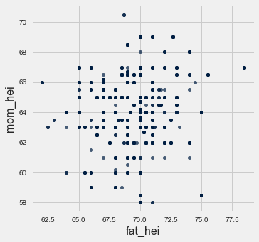

```python
galton.scatter("fat_hei", "mom_hei")
```

If there is an association ("tall men tend to be married to tall women, short men ...") then it's certainly not obvious from the scatterplot. Maybe if we looked at the conditional mean curve?

**Problem** Each father-mother pair with more than one child appears multiple times. So if we simply compute the conditional mean curve of mom_hei given fat_hei, pairs with more children have more influence on the curve. That could potentially make a diffference. So we should make a new dataset where each father-mother pair appears only once. How would we do that?

```python
family_id = galton.column("family")
nchild = galton.num_rows
first_child_row_index = np.zeros(nchild, dtype = int)
family_seqnum = -1
last_family_id = -1
for i in np.arange(nchild):
    if family_id[i] != last_family_id:
        family_seqnum = family_seqnum + 1
        first_child_row_index[family_seqnum] = i
        last_family_id = family_id[i]

nfamily = family_seqnum + 1
first_child_row_index = first_child_row_index[np.arange(nfamily)]
print("Number of families = ", nfamily)
print("Last row of table = ", galton.row(galton.num_rows - 1))
```

```
Number of families =  205
Last row of table =  Row(family='204', fat_hei=62.5, mom_hei=63.0, mid_hei=65.269999999999996, children=2, childNum=2, gender='female', chi_hei=57.0)
```

```python
galton_parents = galton.take(first_child_row_index)
galton_parents.show(10)
```

| family | fat_hei | mom_hei | mid_hei | children | childNum | gender | chi_hei |
| --- | --- | --- | --- | --- | --- | --- | --- |
| 1 | 78.5 | 67 | 75.43 | 4 | 1 | male | 73.2 |
| 2 | 75.5 | 66.5 | 73.66 | 4 | 1 | male | 73.5 |
| 3 | 75 | 64 | 72.06 | 2 | 1 | male | 71 |
| 4 | 75 | 64 | 72.06 | 5 | 1 | male | 70.5 |
| 5 | 75 | 58.5 | 69.09 | 6 | 1 | male | 72 |
| 6 | 74 | 68 | 73.72 | 1 | 1 | female | 69.5 |
| 7 | 74 | 68 | 73.72 | 6 | 1 | male | 76.5 |
| 8 | 74 | 66.5 | 72.91 | 3 | 1 | female | 70.5 |
| 9 | 74.5 | 66 | 72.89 | 1 | 1 | female | 66 |
| 10 | 74 | 65.5 | 72.37 | 1 | 1 | female | 65.5 |

... (195 rows omitted)

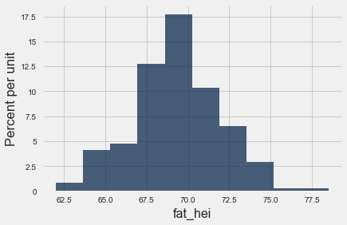

```python
galton_parents.hist("fat_hei")
```

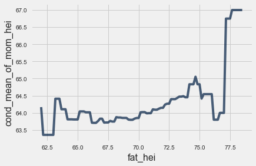

```python
# Now plot conditional mean of mom_hei, give fat_hei

conditional_mean_curve?
bla = conditional_mean_curve(galton_parents, "mom_hei", "fat_hei", 4, plot = True)
```

There are few families with fat_hei outside the interval [65, 74] the conditional means are unreliable because there is not much to average over.

The increase in the curve between 65 and 74 does suggest an association, but is that "real"?

We will address this kind of question soon.